# 2 - Sentiment analysis_SOLVED

2026-02-11

# Sentiment analysis

Let’s do some sentiment analysis using lexicons/dictionaries. This means we work in the word-level.

## 1. Know our lexicons

Before we start analyzing, let’s have a look at some sentiment lexicons. The `tidytext` package provides access to three general-purpose sentiment lexicons:

- AFINN from Finn Årup Nielsen,
- Bing from Bing Liu and collaborators, and
- NRC from Saif Mohammad and Peter Turney.

```r
#we install the necessary packages to work with these lexicons
# install.packages("tidytext")
# install.packages("textdata")
```

The three packages have different approaches to sentiment analysis.

```r
library(tidytext)

get_sentiments("afinn")
```

| word | value |
| --- | --- |
| abandon | -2 |
| abandoned | -2 |
| abandons | -2 |
| abducted | -2 |
| abduction | -2 |
| abductions | -2 |
| abhor | -3 |
| abhorred | -3 |
| abhorrent | -3 |
| abhors | -3 |

[output cut: 2467 more lines]

Afinn is a regression approach. It gives points to words from 5 to -5.

```r
get_sentiments("bing")
```

| word | sentiment |
| --- | --- |
| 2-faces | negative |
| abnormal | negative |
| abolish | negative |
| abominable | negative |
| abominably | negative |
| abominate | negative |
| abomination | negative |
| abort | negative |
| aborted | negative |
| aborts | negative |

[output cut: 6776 more lines]

Bing is a multiclass classification approach on just 2 categories: positive and negative.

```r
get_sentiments("nrc")
```

| word | sentiment |
| --- | --- |
| abacus | trust |
| abandon | fear |
| abandon | negative |
| abandon | sadness |
| abandoned | anger |
| abandoned | fear |
| abandoned | negative |
| abandoned | sadness |
| abandonment | anger |
| abandonment | fear |

[output cut: 9990 more lines]

NRC is a multilabel classification approach in two different levels: it combines sentiment and emotions.

## 2. Extracting sentiment from Jane Austen novels

We will be working on a dataset we created in notebook 1: tokenized Jane Austen novels with columns for the books and chapters the word is coming from. Let’s create it again:

```r
library(janeaustenr)
library(dplyr)
library(stringr)

tidy_austen_books <- austen_books() %>%
  group_by(book) %>%
  mutate(
    linenumber = row_number(),
    chapter = cumsum(str_detect(text,
                                regex("^chapter [\\divxlc]",
                                      ignore_case = TRUE)))) %>%
  ungroup() %>%
  unnest_tokens(word, text)

tidy_austen_books
```

| book | linenumber | chapter | word |
| --- | --- | --- | --- |
| Sense & Sensibility | 1 | 0 | sense |
| Sense & Sensibility | 1 | 0 | and |
| Sense & Sensibility | 1 | 0 | sensibility |
| Sense & Sensibility | 3 | 0 | by |
| Sense & Sensibility | 3 | 0 | jane |
| Sense & Sensibility | 3 | 0 | austen |
| Sense & Sensibility | 5 | 0 | 1811 |
| Sense & Sensibility | 10 | 1 | chapter |
| Sense & Sensibility | 10 | 1 | 1 |
| Sense & Sensibility | 13 | 1 | the |

[output cut: 9990 more lines]

### Joy words in Emma

Now that we have our books tokenized by word, let’s make a question: What are the most common **joy words** Jane Austen used? Let’s take one of the novels, for example, *Emma*.

```r
#we set nrc lexicon to a variable, filtering by joy
nrc_joy <- get_sentiments("nrc") %>%
  filter(sentiment == "joy")

emma_joy_words <- tidy_austen_books %>%
    #we choose the book Emma
    filter(book == "Emma") %>%
    #we combine both lists (all matching rows), NRC and Emma's words
    inner_join(nrc_joy) %>%
    #we count the mentions of each word to find the most frequent
    count(word, sort = TRUE)
emma_joy_words
```

| word | n |
| --- | --- |
| good | 359 |
| friend | 166 |
| hope | 143 |
| happy | 125 |
| love | 117 |
| deal | 92 |
| found | 92 |
| present | 89 |
| kind | 82 |
| happiness | 76 |

[output cut: 291 more lines]

We’ve got a tibble with words and frequencies from *Emma*, filtered only for joy words.

**Exercise**: We want to make a plot combining the last piece of code with ggplot2. We will follow these steps:

1. Start from tidy_austen_books
2. Filter by book *Emma*
3. Combine with nrc_joy
4. Count word frequencies and sort them
5. Filter them by frequency (only mentioned more than X times)
6. Reorder column word by number of mentions (most frequents on top)
7. Create the plot with x=n, y=word

Write the three missing lines of code:

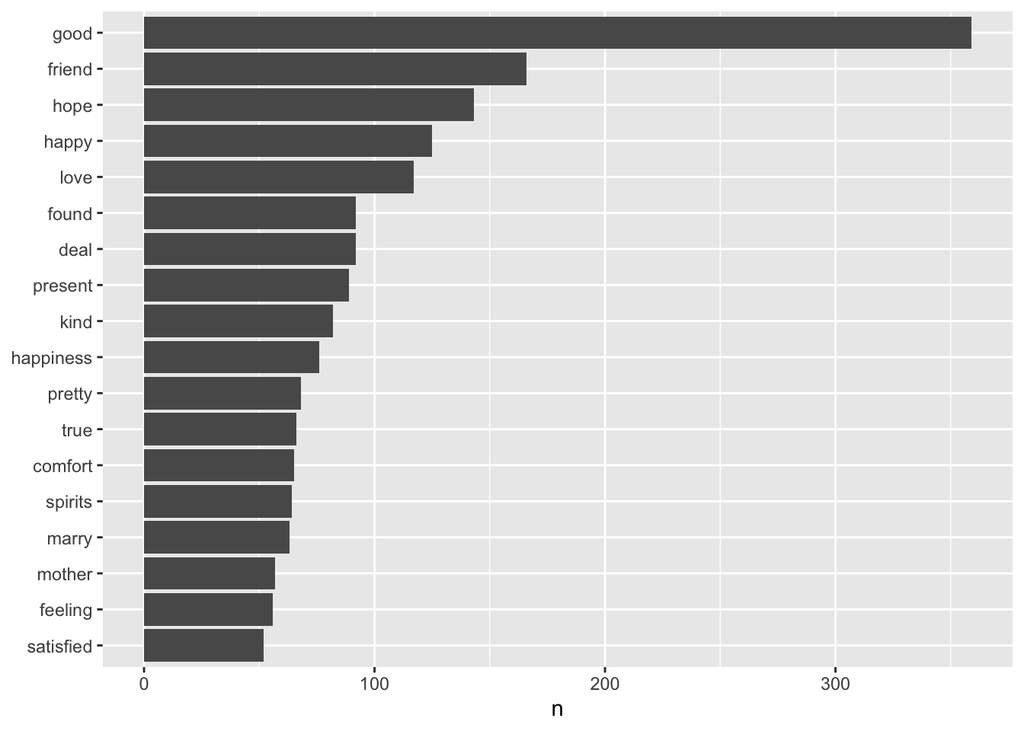

```r
library(ggplot2)

tidy_austen_books %>%
  filter(book == "Emma") %>%
    #we combine both lists, coincident items in NRC and Emma
    inner_join(nrc_joy) %>%
    #we count the mentions to see the most frequent words
    count(word, sort = TRUE) %>%
    #only words mentioned over 50 times in the novel
    filter(n > 50) %>%
    #we reorder words by number of mentions
    mutate(word = reorder(word, n)) %>%
    #we create the plot with the word (x) and the number of mentions (y)
    ggplot(aes(x = n, y = word)) +
    geom_col() +
    labs(y = NULL)
```

### Sentiment distribution in novels

We can also examine how sentiment changes throughout each novel. First, we divide text in chunks and find a sentiment score for each one of them using the Bing lexicon and [`inner_join()`](https://dplyr.tidyverse.org/reference/mutate-joins.html).

```r
library(tidyr)

jane_austen_sentiment <- tidy_austen_books %>%
  #find the sentiment for each word using bing
  inner_join(get_sentiments("bing")) %>%
  #divide each book in chunks of 80 lines assigning an index
  count(book, index = linenumber %/% 80, sentiment) %>%
  #we write positive and negative in different columns
  pivot_wider(names_from = sentiment, values_from = n, values_fill = 0) %>%
  #we substract positive minus negative to find a net sentiment for each chunk
  mutate(sentiment = positive - negative)
jane_austen_sentiment
```

| book | index | negative | positive | sentiment |
| --- | --- | --- | --- | --- |
| Sense & Sensibility | 0 | 16 | 32 | 16 |
| Sense & Sensibility | 1 | 19 | 53 | 34 |
| Sense & Sensibility | 2 | 12 | 31 | 19 |
| Sense & Sensibility | 3 | 15 | 31 | 16 |
| Sense & Sensibility | 4 | 16 | 34 | 18 |
| Sense & Sensibility | 5 | 16 | 51 | 35 |
| Sense & Sensibility | 6 | 24 | 40 | 16 |
| Sense & Sensibility | 7 | 23 | 51 | 28 |
| Sense & Sensibility | 8 | 30 | 40 | 10 |
| Sense & Sensibility | 9 | 15 | 19 | 4 |

[output cut: 910 more lines]

We’ve got everything we need to create plots of sentiment by novel. We can plot these sentiment scores across the plot trajectory of each novel following the chunks of 80 lines.

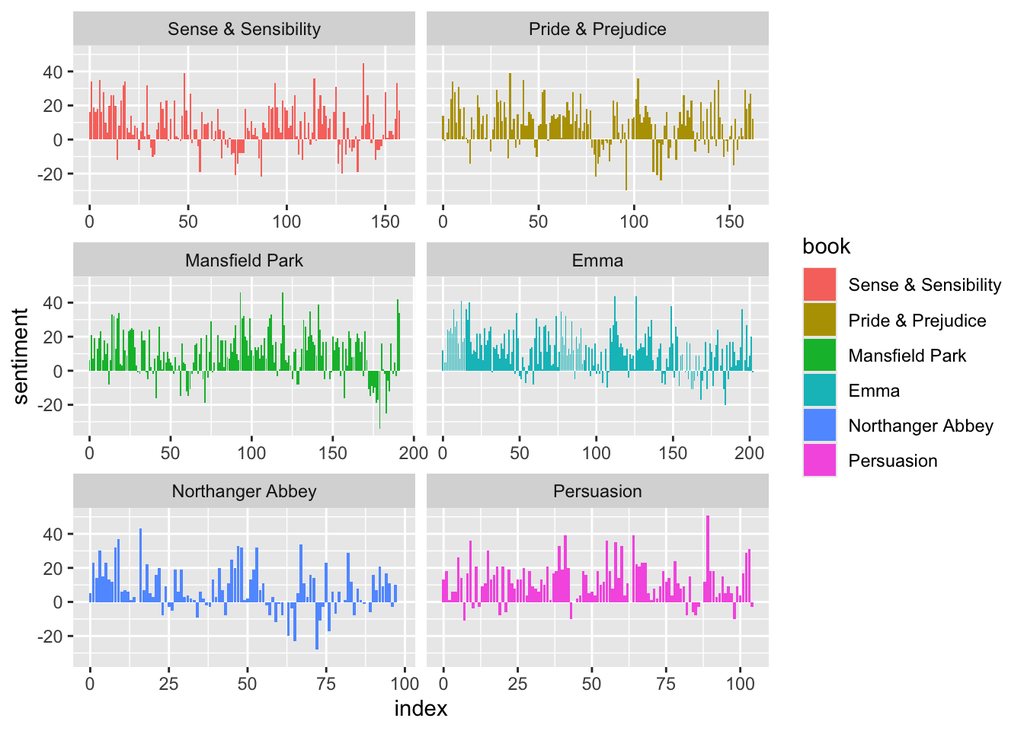

```r
library(ggplot2)
#create the plot with x = index (chunks) and y = net sentiment
ggplot(jane_austen_sentiment, aes(index, sentiment, fill = book)) +
  geom_col(show.legend = TRUE) +
  facet_wrap(~book, ncol = 2, scales = "free_x")
```

Remember we are using the sentiment lexicon “Bing” here. Try to imagine the plot of each novel just by looking at the distribution of sentiment.

**Exercise:** Read the plot, locate the points of conflict for each book and think if they correspond to common narrative structures.